# Visualising and Analysing Time-series Financial Data

Take-home Exercise 4

Zhang Jieyuan  
Feb. 27, 2022

# 1.0 Introduction

The aim is to visualise the impact of of COVID-19 on the stock prices of top 40 companies in Singapore by market capitalisation. The source of data is taken from Yahoo Finance.

# 2.0 Data Preparation

Install the necessary packages.

```r
packages = c('tidyquant','tidyverse','data.table','rmarkdown',"ggHoriPlot","ggthemes","readxl")
for (p in packages) {
  if(!require(p,character.only = T)){
    install.packages(p)
  }
  library(p,character.only = T)
}
```

Using the tq_get() function within the tidyquant R packages to retrieve date, volume, opening, highest, lowest, closing, and adjusted price from Yahoo Finance.

```r
from_date = "2020-01-01"
to_date = "2021-12-31"
period_type = "days"  # "days"/ "weeks"/ "months"/ "years"
stock_selected =c('SE','DBSDF','O39.SI','U11.SI','SNGNF','GRAB','WLMIF','SINGF',
                  'C38U.SI','A17U.SI','SJX.F','BN4.SI','FLEX','SPXCF','G07.SI',
                  'G13.SI','C07.SI','2588.HK','M44U.SI','ME8U.SI','C09.SI',
                  'O32.SI','N2IU.SI','U14.SI','BUOU.SI','T82U.SI','U96.SI',
                  'S58.SI','KLIC','K71U.SI','KEN','RW0U.SI','CJLU.SI','U06.SI',
                  'C52.SI','TDCX','HCTPF','Z25.SI','KARO','TRIT'
)


stock_data_daily = tq_get(stock_selected,
               get = "stock.prices",
               from = from_date,
               to = to_date)

paged_table(stock_data_daily)
```

| symbol | date | open | high | low | close | volume | adjusted |
| --- | --- | --- | --- | --- | --- | --- | --- |
| SE | 2020-01-02 | 41.000000 | 41.189999 | 39.459999 | 40.040001 | 5857000 | 40.040001 |
| SE | 2020-01-03 | 39.439999 | 40.650002 | 39.400002 | 40.490002 | 5237800 | 40.490002 |
| SE | 2020-01-06 | 40.070000 | 41.029999 | 40.028999 | 40.480000 | 4049200 | 40.480000 |
| SE | 2020-01-07 | 40.500000 | 41.799999 | 40.349998 | 41.009998 | 3947600 | 41.009998 |
| SE | 2020-01-08 | 41.000000 | 41.389000 | 40.055000 | 40.160000 | 3200800 | 40.160000 |
| SE | 2020-01-09 | 40.790001 | 40.900002 | 40.040001 | 40.529999 | 3129700 | 40.529999 |
| SE | 2020-01-10 | 40.759998 | 40.910000 | 39.340000 | 39.580002 | 3360900 | 39.580002 |
| SE | 2020-01-13 | 39.709999 | 40.365002 | 39.599998 | 40.020000 | 1647300 | 40.020000 |
| SE | 2020-01-14 | 40.000000 | 40.270000 | 39.150002 | 39.939999 | 3445800 | 39.939999 |
| SE | 2020-01-15 | 40.400002 | 40.950001 | 39.910000 | 40.419998 | 2312300 | 40.419998 |

[output cut: 9990 more lines]

Calculate the changes closing vs opening of daily stock price and the percentage changes.

```r
stock_data_daily$diff<-stock_data_daily$close - stock_data_daily$open

stock_data_daily$diff_percent<-(stock_data_daily$close - stock_data_daily$open)/stock_data_daily$open
```

Import excel file with the name of the stocks and the category of the stock found [here](https://companiesmarketcap.com/singapore/largest-companies-in-singapore-by-market-cap/).

```r
stock<-read_excel("Stocks.xlsx")
```

Left join the Stocks dataframe with stock_data_daily data to map the name and sector of the stock.

```r
stock_data_daily<-stock_data_daily %>%
  left_join(stock, c("symbol"="StockTick"))
```

# 3.0 Plotting Horizon Graph

## 3.1 Horizon Graph on Stock Price

Using ggHoriPlotp package, the plot shows historical adjusted stock prices of the top 40 companies in SG by market capitalization from Jan 2020 to Dec 2021. The sectors are also added in to compare how stock price for stocks in different sectors impacted by COVID 19 and recovers.

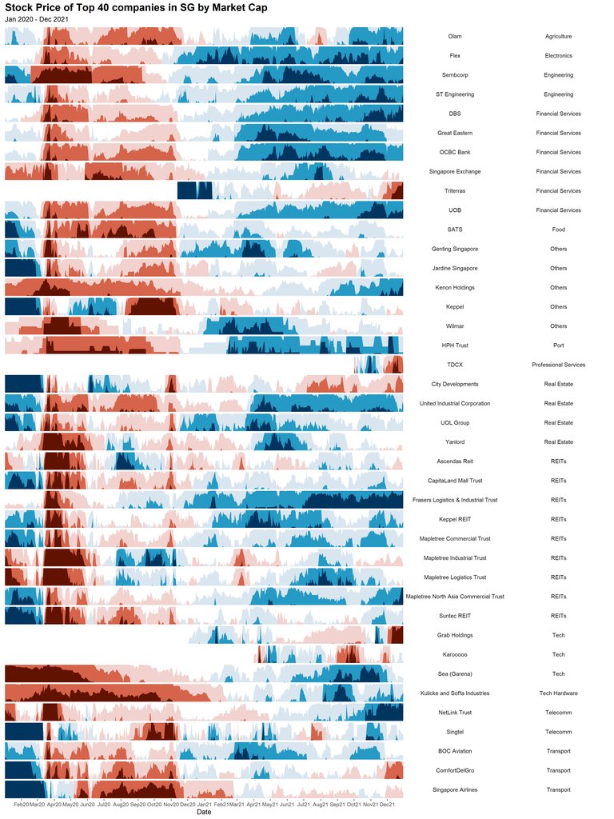

```r
stock_data_daily%>%
  ggplot() +
  geom_horizon(aes(date,
                   adjusted), rm.outliers = T) +
  scale_fill_hcl(palette = 'RdBu') +
  facet_grid(Sector+StockName~.)+
  theme_few() +
  theme(
    panel.spacing.y=unit(0, "lines"),
    strip.text.y = element_text(size = 10, angle = 0),
    legend.position = 'none',
    axis.text.y = element_blank(),
    axis.title.y = element_blank(),
    axis.ticks.y = element_blank(),
    panel.border = element_blank(),panel.grid = element_blank(),
    plot.title = element_text(color="black", size=18, face="bold")
    ) +
  scale_x_date(expand=c(0,0), date_breaks = "1 month", date_labels = "%b%y") +
  xlab('Date')+
  ggtitle('Stock Price of Top 40 companies in SG by Market Cap',
          'Jan 2020 - Dec 2021')
```

Using the horizon graph, we can observe that most stocks have relatively lower stock price after Feb 2020 when Covid 19 hits and recovers with relative higher price in 2021.

## 3.1 Horizon Graph on Stock Price Changes

Another Horizon plot is added to examine the changes in stock price by plotting the difference in closing and opening daily price.

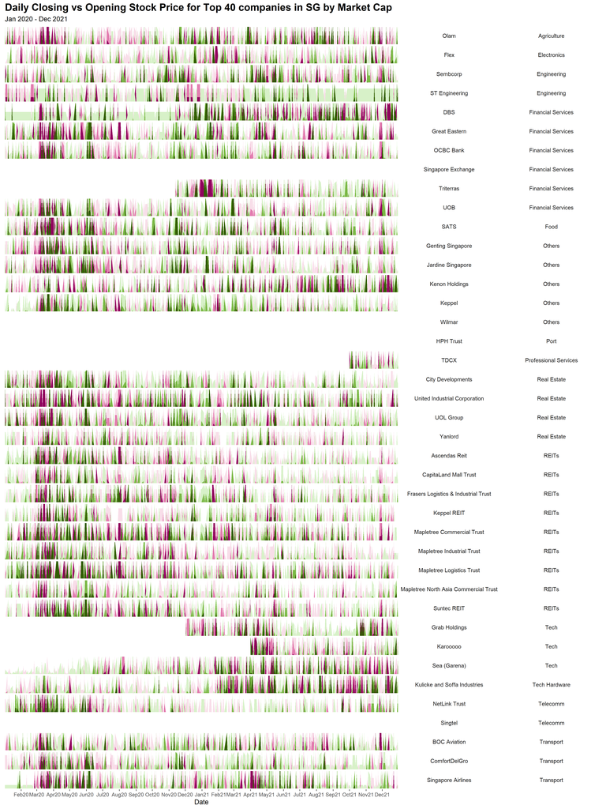

```r
stock_data_daily%>%
  ggplot() +
  geom_horizon(aes(date,
                   diff), rm.outliers = T) +
  scale_fill_hcl(palette = 'PiYG') +
  facet_grid(Sector+StockName~.)+
  theme_few() +
  theme(
    panel.spacing.y=unit(0, "lines"),
    strip.text.y = element_text(size = 10, angle = 0),
    legend.position = 'none',
    axis.text.y = element_blank(),
    axis.title.y = element_blank(),
    axis.ticks.y = element_blank(),
    panel.border = element_blank(),panel.grid = element_blank(),
    plot.title = element_text(color="black", size=18, face="bold")
    ) +
  scale_x_date(expand=c(0,0), date_breaks = "1 month", date_labels = "%b%y") +
  xlab('Date')+
  ggtitle('Daily Closing vs Opening Stock Price for Top 40 companies in SG by Market Cap',
          'Jan 2020 - Dec 2021')
```

# 4.0 Conclusion and Learning

Horizon graph enables us to plot time series graph and compare the trend across multiple charts( which reflects different stocks in this case). While it is interesting and make use of different color densities, it might not be intuitive in interpreting the result of horizon graph if the reader is seeing it for the first time.